# Lab 4 - Hidden Markov Models

Maria Kuruvilla, Miranda Mudge

May 9, 2023

# Data

Here we will examine a model fitting 3 different local copepod metrics - copepod richness, northern copepod biomass, and southern copepod biomass - across the entire available time series. After spending some time looking at the time-series patterns prior to model fitting, we would also like to evaluate the effect of Pacific Decadal Oscillation (PDO) from December to March as a covariate on both the state and transition. We will evaluate both a 2 and 3 state model with 1 covariate.

## Note

The variables we chose were already de-meaned. We did not zscore the data.

## Wrangle the data

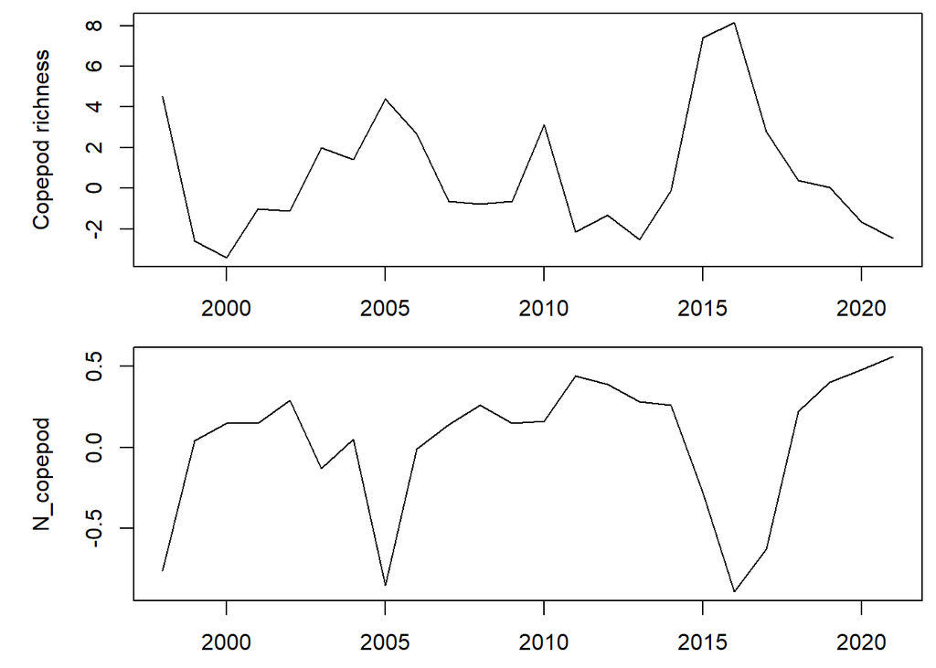

```r
rownames(stoplight) <- stoplight[,1]

subset_data <- stoplight[c("Copepod_richness","N_copepod","S_copepod","PDO_DecMarch"),3:26]

#column names should be years
colnames(subset_data) <- seq(1998,2021)

par(mfrow = c(2,1), mai = c(0.5, 1, 0.1, 0.1), omi = c(0, 0, 0, 0))
plot(seq(1998,2021),subset_data["Copepod_richness",], type = "l", xlab = "years", ylab ="Copepod richness")
plot(seq(1998,2021),subset_data["N_copepod",], type = "l", xlab = "years", ylab ="N_copepod")
```

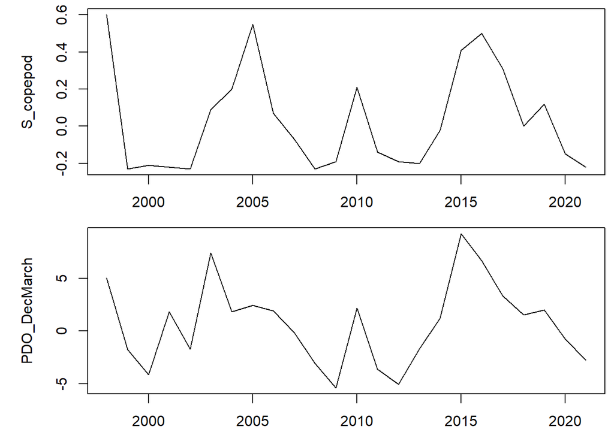

```r
plot(seq(1998,2021),subset_data["S_copepod",], type = "l", xlab = "years", ylab ="S_copepod")
plot(seq(1998,2021),subset_data["PDO_DecMarch",], type = "l", xlab = "years", ylab ="PDO_DecMarch")
```

# Univariate test

We will start by looking at copepod richness.

```r
data <- data.frame(t(subset_data))
fitmod <- depmix(Copepod_richness ~1,
                 nstates = 2,
                 transition = ~ 1,
                 family = gaussian(),
                 data = data)
```

```r
set.seed(123)
fit1 <- fit(fitmod)
```

```
## converged at iteration 18 with logLik: -54.68034
```

```r
pars <- getpars(fit1)
matrix(pars[3:6], 2, 2, byrow = TRUE)
```

```
##           [,1]      [,2]
## [1,] 0.7536262 0.2463738
## [2,] 0.4021802 0.5978198
```

```r
AIC1 <- AIC(fitmod)
```

Here we look at the effect of 1 covariate on copepod richness.

```r
fitmod_cov <- depmix(Copepod_richness ~1 + PDO_DecMarch,
                 nstates = 2,
                 transition = ~ 1,
                 family = gaussian(),
                 data = data)
```

```r
set.seed(123)
fit_cov <- fit(fitmod_cov)
```

```
## converged at iteration 40 with logLik: -41.20702
```

```r
pars_cov <- getpars(fit_cov)
matrix(pars_cov[3:6], 2, 2, byrow = TRUE)
```

```
##           [,1]      [,2]
## [1,] 0.4533026 0.5466974
## [2,] 0.3606362 0.6393638
```

```r
AIC_cov <- AIC(fitmod_cov)
```

# Reframe multivariate dataset

Wrangle data to multivariate subset.

```r
subset_data_l <- subset_data
subset_data_l$ID <- rownames(subset_data_l)

subset_data_long <- subset_data_l %>%
  pivot_longer(!ID, names_to = "variable",
               values_to = "value")


subset_multi <-pivot_wider(subset_data_long, names_from = ID, values_from = value, names_repair = "check_unique")
```

# HMM on 2 states

Basic 2 state model

```r
set.seed(123)
mod2_1 = depmix(list(Copepod_richness ~ 1, N_copepod~1, S_copepod~1),
             nstates = 2,
             family = list(gaussian(),gaussian(),gaussian()),
             data=subset_multi)
fitmod2_1 = fit(mod2_1)
```

```
## converged at iteration 6 with logLik: -36.64126
```

```r
AIC2_1 = AIC(fitmod2_1)
```

```r
prstates = apply(posterior(fitmod2_1)[,c("S1","S2")], 1, which.max)
```

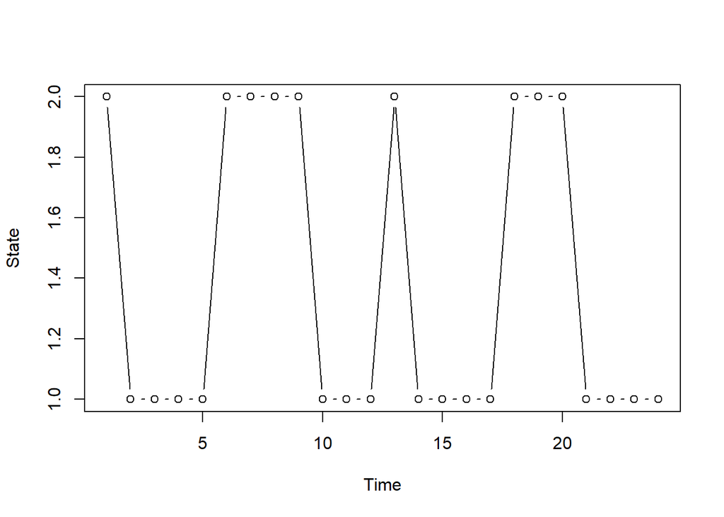

```r
plot(prstates, type="b", xlab="Time", ylab="State")
```

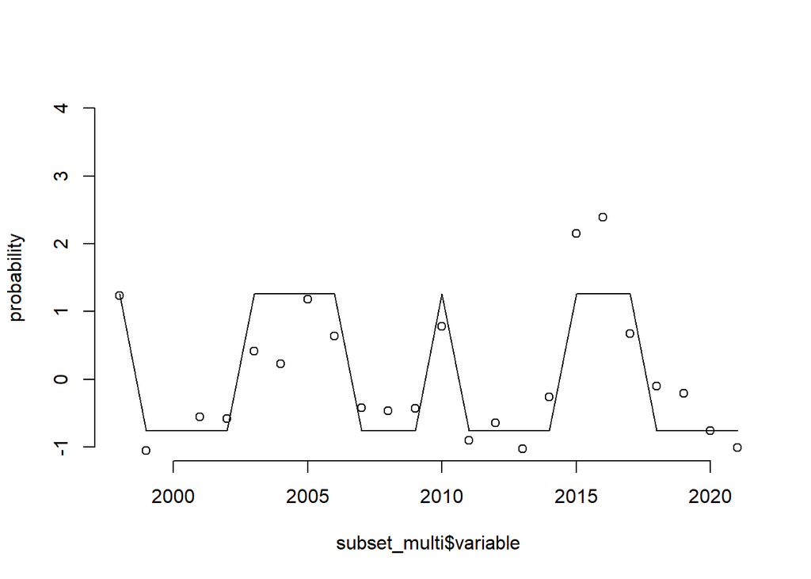

```r
plot(subset_multi$variable, scale(apply(posterior(fitmod2_1) [,c("S1", "S2")], 1, which.max)),
     ylab="probability",
frame=FALSE, ylim = c(-1,4), type = "l")
points(subset_multi$variable,scale(subset_multi$Copepod_richness))
```

HMM with 2 states and covariate

```r
set.seed(123)
mod2_2 = depmix(list(Copepod_richness ~ PDO_DecMarch, N_copepod~ PDO_DecMarch,
                     S_copepod~PDO_DecMarch),
             nstates = 2,
             family = list(gaussian(),gaussian(),gaussian()),
             data=subset_multi)
fitmod2_2 = fit(mod2_2)
```

```
## converged at iteration 23 with logLik: -16.51386
```

```r
AIC2_2 = AIC(fitmod2_2)
```

Covariate in the transition probabilty

```r
set.seed(123)
mod2_3 = depmix(list(Copepod_richness ~ 1, N_copepod ~ 1,
                     S_copepod ~ 1),
             nstates = 2,
             transition = ~PDO_DecMarch,
             family = list(gaussian(),gaussian(),gaussian()),
             data=subset_multi)
fitmod2_3 = fit(mod2_3)
```

```
## converged at iteration 6 with logLik: -35.52724
```

```r
AIC2_3 = AIC(fitmod2_3)
```

# HMM on 3 states

Basic 3 state model

```r
set.seed(123)
mod3_1 = depmix(list(Copepod_richness ~ 1, N_copepod~1, S_copepod~1),
             nstates = 3,
             family = list(gaussian(),gaussian(),gaussian()),
             data=subset_multi)
fitmod3_1 = fit(mod3_1)
```

```
## converged at iteration 13 with logLik: -14.21542
```

```r
AIC3_1 <- AIC(fitmod3_1)
```

## Effect of covariate on transition parameters

3 state model with covariate effects on transition parameters

```r
set.seed(123)
mod3_2 = depmix(list(Copepod_richness ~ 1, N_copepod~1, S_copepod~1),
             nstates = 3,
             family = list(gaussian(),gaussian(),gaussian()),
             transition = ~scale(PDO_DecMarch),
             data=subset_multi)
fitmod3_2 = fit(mod3_2)
summary(fitmod3_2, which = "transition")
```

```
## Transition model for state (component) 1
## Model of type multinomial (mlogit), formula: ~scale(PDO_DecMarch)
## Coefficients:
##                     St1       St2       St3
## (Intercept)           0 -2.050474 -3.214950
## scale(PDO_DecMarch)   0  2.953207 -1.822716
## Probalities at zero values of the covariates.
## 0.8555555 0.1100877 0.03435684
##
## Transition model for state (component) 2
## Model of type multinomial (mlogit), formula: ~scale(PDO_DecMarch)
## Coefficients:
##                     St1       St2       St3
## (Intercept)           0 -54.41624  37.84036
## scale(PDO_DecMarch)   0  41.09343 -66.67456
## Probalities at zero values of the covariates.
## 3.682484e-17 8.579653e-41 1
##
## Transition model for state (component) 3
## Model of type multinomial (mlogit), formula: ~scale(PDO_DecMarch)
## Coefficients:
##                     St1       St2       St3
## (Intercept)           0  168.1468 -23.27279
## scale(PDO_DecMarch)   0 -548.7562  22.54852
## Probalities at zero values of the covariates.
## 9.435514e-74 1 7.370907e-84
```

```r
summary(fitmod3_2, which = "response")
```

```
## Response parameters
## Resp 1 : gaussian
## Resp 2 : gaussian
## Resp 3 : gaussian
##     Re1.(Intercept) Re1.sd Re2.(Intercept) Re2.sd Re3.(Intercept) Re3.sd
## St1          -1.329  1.066           0.281  0.142          -0.145  0.102
## St2           5.458  2.010          -0.682  0.220           0.474  0.103
## St3           2.302  0.650           0.018  0.105           0.142  0.063
```

```r
AIC3_2 <- AIC(fitmod3_2)
```

3 state model with covariate effects on state parameters

```r
set.seed(123)
mod3_3 = depmix(list(Copepod_richness ~ 1 +PDO_DecMarch,
                     N_copepod~1 +PDO_DecMarch,
                     S_copepod~1+PDO_DecMarch),
             nstates = 3,
             family = list(gaussian(),gaussian(),gaussian()),
             data=subset_multi)
fitmod3_3 = fit(mod3_3)
```

```
## converged at iteration 11 with logLik: 2.504683
```

```r
summary(fitmod3_3, which = "transition")
```

```
## Transition matrix
##         toS1  toS2 toS3
## fromS1 0.666 0.334  0.0
## fromS2 0.500 0.000  0.5
## fromS3 0.400 0.400  0.2
```

```r
summary(fitmod3_3, which = "response")
```

```
## Response parameters
## Resp 1 : gaussian
## Resp 2 : gaussian
## Resp 3 : gaussian
##     Re1.(Intercept) Re1.PDO_DecMarch Re1.sd Re2.(Intercept) Re2.PDO_DecMarch
## St1          -1.082            0.449  0.553           0.246           -0.033
## St2           1.358            0.623  0.540           0.148           -0.045
## St3           2.330            0.622  1.165          -0.385           -0.087
##     Re2.sd Re3.(Intercept) Re3.PDO_DecMarch Re3.sd
## St1  0.153          -0.108            0.030  0.081
## St2  0.055           0.022            0.047  0.073
## St3  0.127           0.201            0.063  0.121
```

```r
AIC3_3 <- AIC(fitmod3_3)
```

3 state model with covariate effects on state and transition parameters

```r
set.seed(123)
mod3_4 = depmix(list(Copepod_richness ~ 1 +PDO_DecMarch,
                     N_copepod~1 +PDO_DecMarch,
                     S_copepod~1+PDO_DecMarch),
             nstates = 3,
             family = list(gaussian(),gaussian(),gaussian()),
             transition = ~scale(PDO_DecMarch),
             data=subset_multi)
fitmod3_4 = fit(mod3_4)
```

```
## converged at iteration 9 with logLik: 6.771089
```

```r
summary(fitmod3_4, which = "transition")
```

```
## Transition model for state (component) 1
## Model of type multinomial (mlogit), formula: ~scale(PDO_DecMarch)
## Coefficients:
##                     St1       St2       St3
## (Intercept)           0 -14.28446 -4.780849
## scale(PDO_DecMarch)   0  13.85850 -3.743221
## Probalities at zero values of the covariates.
## 0.9916803 6.204519e-07 0.008319078
##
## Transition model for state (component) 2
## Model of type multinomial (mlogit), formula: ~scale(PDO_DecMarch)
## Coefficients:
##                     St1       St2        St3
## (Intercept)           0 8.9479395 10.0956666
## scale(PDO_DecMarch)   0 0.4193047  0.2601215
## Probalities at zero values of the covariates.
## 3.131775e-05 0.2408969 0.7590718
##
## Transition model for state (component) 3
## Model of type multinomial (mlogit), formula: ~scale(PDO_DecMarch)
## Coefficients:
##                     St1       St2        St3
## (Intercept)           0 -346.3149 -23.353137
## scale(PDO_DecMarch)   0 -228.5024   5.163639
## Probalities at zero values of the covariates.
## 1 3.956941e-151 7.208778e-11
```

```r
summary(fitmod3_4, which = "response")
```

```
## Response parameters
## Resp 1 : gaussian
## Resp 2 : gaussian
## Resp 3 : gaussian
##     Re1.(Intercept) Re1.PDO_DecMarch Re1.sd Re2.(Intercept) Re2.PDO_DecMarch
## St1          -0.644            0.643  1.205           0.212           -0.041
## St2           0.898            0.987  0.784           0.160           -0.125
## St3           1.908            0.536  0.724          -0.331           -0.109
##     Re2.sd Re3.(Intercept) Re3.PDO_DecMarch Re3.sd
## St1  0.155          -0.100            0.044  0.086
## St2  0.203           0.083            0.062  0.004
## St3  0.158           0.210            0.075  0.099
```

```r
AIC3_4 <- AIC(fitmod3_4)
```

```r
AIC2_1
```

```
## [1] 103.2825
```

```r
AIC2_2
```

```
## [1] 75.02772
```

```r
AIC2_3
```

```
## [1] 105.0545
```

```r
AIC3_1
```

```
## [1] 80.43083
```

```r
AIC3_2
```

```
## [1] 121.6923
```

```r
AIC3_3 # best model
```

```
## [1] 64.99063
```

```r
AIC3_4
```

```
## [1] 68.45782
```

```r
print(fitmod3_3)
```

```
## Convergence info: Log likelihood converged to within tol. (relative change)
## 'log Lik.' 2.504683 (df=35)
## AIC:  64.99063
## BIC:  106.2225
```

Plotting the 3 state model

```r
prstates = apply(posterior(fitmod3_3)[,c("S1","S2", "S3")], 1, which.max)
```

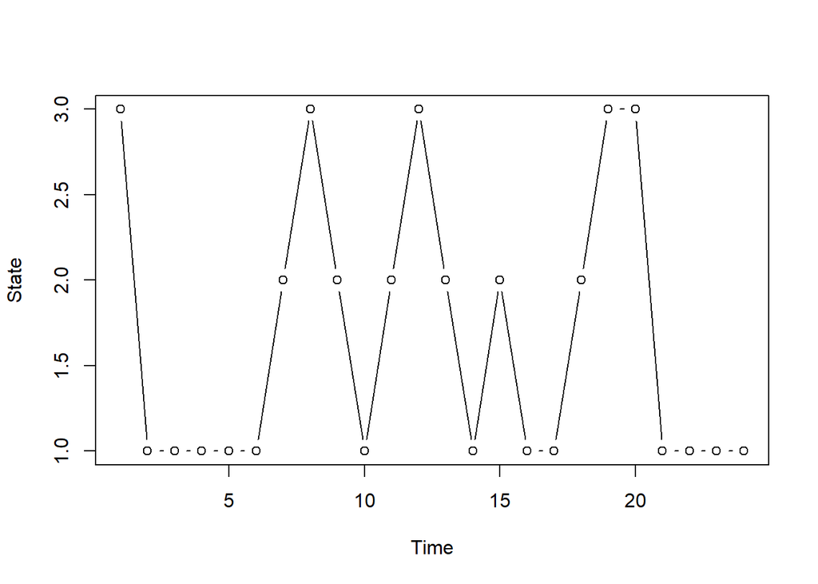

```r
plot(prstates, type="b", xlab="Time", ylab="State")
```

Based on the AIC values, the best model for assessing our subset of copepod data is the multivariate 3 state HMM model with covariate effects on the state parameters.

# Results / Discussion

Does it converge?

- Yes, all our models converge.

How many states seem to be most supported?

- An HMM model with 3 states is the most supported by AIC comparison but the fit looks better with a 2 state model.

Plot the time series of estimated states.

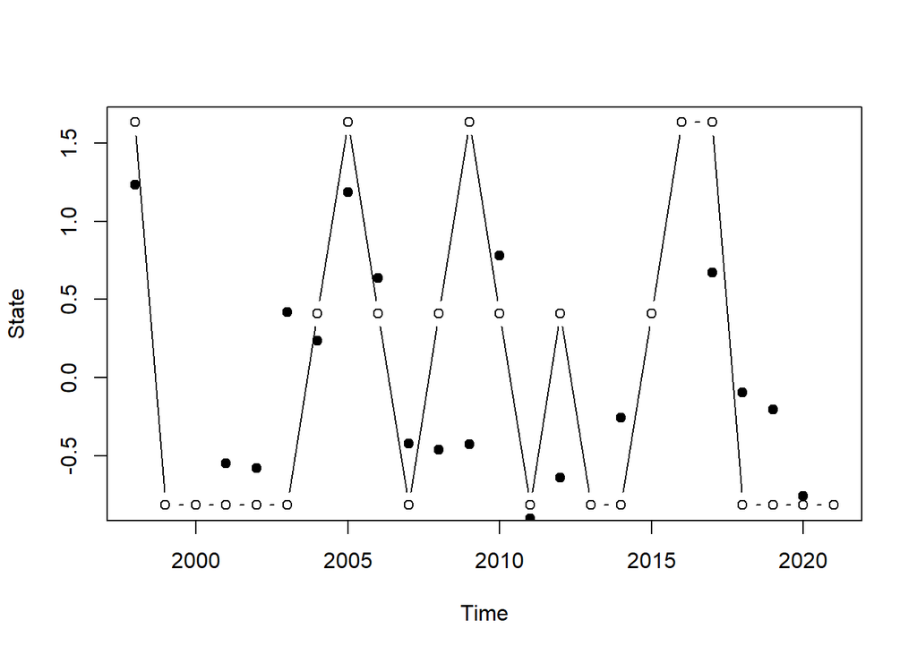

```r
prstates = apply(posterior(fitmod3_3)[,c("S1","S2", "S3")], 1, which.max)
plot(subset_multi$variable,scale(apply(posterior(fitmod3_3)[,c("S1","S2", "S3")], 1, which.max)), xlab="Time", ylab="State", type = "b")
points(subset_multi$variable,scale(subset_multi$Copepod_richness), pch = 19)
```

What does this mean? - The 3 state model shows that shows a smooth transition between states 1 - 3. While the transition probabilities below show that it is possible for the model to jump from state 3 to state 1, the opposite is not true (probability of moving from state 1 to state 3 is zero). This is reflected when plotting the likely states. It is more likely to switch smoothly between the states over time, which makes sense when considering the influence of PDO - which indicates an overall warm or cool phase of ocean activity. It is more likely that temperature fluctuations have smooth transitions than drastic jumps over a large time scale, and this is reflected in the 3 state model. It also explains why the 2 state model with the same covariate effects also fits the data well - eliminating the middle state from a time series with smooth transitions shouldn’t drastically effect the model.

What are the transition probabilities? - Our transition matrix for the 3 state model:

$$\begin{bmatrix}
0.66 & 0.33 & 0 \\
0.5 & 0 & 0.5 \\
0.4 & 0.4 & 0.2 \\
\end{bmatrix}$$

If included, what are the covariate effects? What do these mean? - We evaluated the effect of the climate covariate Pacific Decadal Oscillation (PDO) from December to March and found that PDO allowed the HMM model to have a better fit to the data when influencing the state process.

Anything else interesting that you’ve discovered? - In both the 2 and 3 state HMM models, the covariate effects were best explained as state effects.

# Team contributions

Miranda and Maria both decided on the variables and covariates to test. Maria fit the 2 state model and Miranda fit the 3 state model. Miranda drafted the contributions into a final report. Maria wrote the discussion and finalized the report.